# Transparency of COVID-19-related research - Analysis

Ahmad Sofi-Mahmudi, Eero Raittio, Sergio E Uribe

2022-02-11

# Loading required packages

```r
pacman::p_load(dplyr,
               ggplot2,
               knitr)
```

# Loading the datasets

First, set working directory to the folder that has all the datasets in it using setwd() function and then run the following code:

```r
opendata <- read.csv("covid_transparency_opendata.csv")
```

# Results

Number of all papers (open access and non open access), open-access papers and open-access percentage:

```r
kable(data.frame(hits_all = 92752,
           hits_oa = nrow(opendata),
           oa_percentage = round((nrow(opendata)/92752)*100, 2)))
```

| hits_all | hits_oa | oa_percentage |
| --- | --- | --- |
| 92752 | 72999 | 78.7 |

First, adding the real publication year and month to the datasets. The real publication year/month is the year/month the paper was first appear online stored in firstPublicationDate column.

```r
library(lubridate)
opendata <- opendata %>%
  mutate(year_firstpub = year(
    as.POSIXlt(firstPublicationDate,
               format = "%Y-%m-%d")),
    month_firstpub = month(
      as.POSIXlt(firstPublicationDate,
               format = "%Y-%m-%d")
    )
    )
```

Number of open access papers per year:

```r
kable(table(opendata$year_firstpub))
```

| Var1 | Freq |
| --- | --- |
| 2020 | 33114 |
| 2021 | 39885 |

The number of journals in our dataset:

```r
length(table(opendata$journal))
```

```
## [1] 4892
```

Top 10 journals with the highest number of articles in our dataset, from high to low:

```r
kable(head(table(opendata$journal) %>% as.data.frame() %>% arrange(desc(Freq)), 10))
```

| Var1 | Freq |
| --- | --- |
| PLoS ONE | 6825 |
| International Journal of Environmental Research and Public Health | 2686 |
| Medicine | 2318 |
| BMJ Open | 1926 |
| eLife | 942 |
| Scientific Reports | 856 |
| JAMA Network Open | 800 |
| Journal of Clinical Medicine | 797 |
| Cureus | 757 |
| Nutrients | 708 |

The mean and the median of the number of citations to these references:

```r
kable(data.frame(Mean = round(mean(opendata$citedByCount),1),
           SD = round(sd(opendata$citedByCount), 2),
           Median = median(opendata$citedByCount),
           IQR = IQR(opendata$citedByCount)
           ))
```

| Mean | SD | Median | IQR |
| --- | --- | --- | --- |
| 3.1 | 21.76 | 0 | 2 |

Characteristics of the paper with the highest number of citations:

```r
kable(opendata[which.max(opendata$citedByCount),] %>%
  select(pmid, pmcid, doi.x, title, authorString, journalTitle, pubYear))
```

|  | pmid | pmcid | doi.x | title | authorString | journalTitle | pubYear |
| --- | --- | --- | --- | --- | --- | --- | --- |
| 4126 | 32155444 | PMC7102599 | 10.1016/j.cell.2020.02.058 | Structure, Function, and Antigenicity of the SARS-CoV-2 Spike Glycoprotein. | Walls AC, Park YJ, Tortorici MA, Wall A, McGuire AT, Veesler D. | Cell | 2020 |

The number and percentage of papers with a conflict of interest (CoI) disclosure:

```r
kable(data.frame(
  number = length(opendata$is_coi_pred[opendata$is_coi_pred == TRUE]),
           percentage = round(length(opendata$is_coi_pred[opendata$is_coi_pred == TRUE])/nrow(opendata)*100, 2)
           ))
```

| number | percentage |
| --- | --- |
| 67009 | 91.79 |

Confidence interval for CoI:

```r
library(epiR)
kable(round(epi.prev(pos = length(opendata$is_coi_pred[opendata$is_coi_pred == TRUE]),
         tested = nrow(opendata),
         se = 0.992,
         sp = 0.995)$ap,
      2))
```

| est | lower | upper |
| --- | --- | --- |
| 91.79 | 91.59 | 91.99 |

Comparing CoI disclosure rate in two years:

```r
kable(round(prop.table(table(opendata$is_coi_pred, opendata$year_firstpub), 2)*100, 1))
```

|  | 2020 | 2021 |
| --- | --- | --- |
| FALSE | 9.9 | 6.8 |
| TRUE | 90.1 | 93.2 |

Chi-square test:

```r
chisq.test(opendata$is_coi_pred, opendata$year_firstpub)
```

```
##
##  Pearson's Chi-squared test with Yates' continuity correction
##
## data:  opendata$is_coi_pred and opendata$year_firstpub
## X-squared = 237.82, df = 1, p-value < 2.2e-16
```

The number and percentage of papers with a funding statement:

```r
kable(data.frame(number = length(opendata$is_fund_pred[opendata$is_fund_pred == TRUE]),
           percentage = round(length(opendata$is_fund_pred[opendata$is_fund_pred == TRUE])/nrow(opendata)*100, 2)
           ))
```

| number | percentage |
| --- | --- |
| 60530 | 82.92 |

Confidence interval for funding statement:

```r
kable(round(epi.prev(pos = length(opendata$is_fund_pred[opendata$is_fund_pred == TRUE]),
         tested = nrow(opendata),
         se = 0.997,
         sp = 0.981)$ap,
      2))
```

| est | lower | upper |
| --- | --- | --- |
| 82.92 | 82.64 | 83.19 |

Comparing funding statement rate in two years:

```r
kable(round(prop.table(table(opendata$is_fund_pred, opendata$year_firstpub), 2)*100, 1))
```

|  | 2020 | 2021 |
| --- | --- | --- |
| FALSE | 18.3 | 16.1 |
| TRUE | 81.7 | 83.9 |

Chi-square test:

```r
chisq.test(opendata$is_fund_pred, opendata$year_firstpub)
```

```
##
##  Pearson's Chi-squared test with Yates' continuity correction
##
## data:  opendata$is_fund_pred and opendata$year_firstpub
## X-squared = 60.357, df = 1, p-value = 7.911e-15
```

The number and percentage of papers that were registered beforehand:

```r
kable(data.frame(number = length(opendata$is_register_pred[opendata$is_register_pred == TRUE]),
           percentage = round(length(opendata$is_register_pred[opendata$is_register_pred == TRUE])/nrow(opendata)*100, 2)
           ))
```

| number | percentage |
| --- | --- |
| 11457 | 15.69 |

Confidence interval for registration:

```r
kable(round(epi.prev(pos = length(opendata$is_register_pred[opendata$is_register_pred == TRUE]),
         tested = nrow(opendata),
         se = 0.955,
         sp = 0.997)$ap,
      2))
```

| est | lower | upper |
| --- | --- | --- |
| 15.69 | 15.43 | 15.96 |

Comparing registration rate in two years:

```r
kable(round(prop.table(table(opendata$is_register_pred, opendata$year_firstpub), 2)*100, 1))
```

|  | 2020 | 2021 |
| --- | --- | --- |
| FALSE | 85 | 83.8 |
| TRUE | 15 | 16.2 |

Chi-square test:

```r
chisq.test(opendata$is_register_pred, opendata$year_firstpub)
```

```
##
##  Pearson's Chi-squared test with Yates' continuity correction
##
## data:  opendata$is_register_pred and opendata$year_firstpub
## X-squared = 19.608, df = 1, p-value = 9.509e-06
```

The number and percentage of papers that shared data (preliminary):

```r
kable(data.frame(number = length(opendata$is_open_data[opendata$is_open_data == TRUE]),
           percentage = round(length(opendata$is_open_data[opendata$is_open_data == TRUE])/nrow(opendata)*100, 2)
           ))
```

| number | percentage |
| --- | --- |
| 9493 | 13 |

Comparing data sharing rate in two years (preliminary):

```r
kable(round(prop.table(table(opendata$is_open_data, opendata$year_firstpub), 2)*100, 1))
```

|  | 2020 | 2021 |
| --- | --- | --- |
| FALSE | 87.2 | 86.8 |
| TRUE | 12.8 | 13.2 |

The number and percentage of papers that shared code (preliminary):

```r
kable(data.frame(number = length(opendata$is_open_code[opendata$is_open_code == TRUE]),
           percentage = round(length(opendata$is_open_code[opendata$is_open_code == TRUE])/nrow(opendata)*100, 2)
           ))
```

| number | percentage |
| --- | --- |
| 2264 | 3.1 |

Comparing code sharing rate in two years (preliminary):

```r
kable(round(prop.table(table(opendata$is_open_code, opendata$year_firstpub), 2)*100, 1))
```

|  | 2020 | 2021 |
| --- | --- | --- |
| FALSE | 97.2 | 96.7 |
| TRUE | 2.8 | 3.3 |

## Journal Impact Factor (JIF) analyses

First, importing jif file:

```r
jif <- read.csv("jif_2020.csv")
```

Merging it with opendata:

```r
db_jif <- merge(opendata, jif, by.x = "journalIssn", by.y = "ISSN")
db_jif$X2020.JIF <- as.numeric(db_jif$X2020.JIF)
```

Total number of papers published in journals with no JIF:

```r
nrow(opendata) - nrow(db_jif)
```

```
## [1] 51601
```

JIF based on COI disclosure:

```r
kable(db_jif %>%
  group_by(is_coi_pred) %>%
  summarise(Mean = round(mean(X2020.JIF, na.rm = T),3),
            SD = round(sd(X2020.JIF, na.rm = T),4),
            Median = median(X2020.JIF, na.rm = T),
            IQR = IQR(X2020.JIF, na.rm = T)))
```

| is_coi_pred | Mean | SD | Median | IQR |
| --- | --- | --- | --- | --- |
| FALSE | 7.442 | 2.1377 | 8.483 | 0.000 |
| TRUE | 4.097 | 2.0086 | 3.709 | 2.253 |

Test for normality:

```r
set.seed(10)

with(db_jif, shapiro.test(sample(X2020.JIF[is_coi_pred == TRUE], 5000)))
```

```
##
##  Shapiro-Wilk normality test
##
## data:  sample(X2020.JIF[is_coi_pred == TRUE], 5000)
## W = 0.75943, p-value < 2.2e-16
```

```r
with(db_jif, shapiro.test(X2020.JIF[is_coi_pred == FALSE]))
```

```
##
##  Shapiro-Wilk normality test
##
## data:  X2020.JIF[is_coi_pred == FALSE]
## W = 0.58087, p-value < 2.2e-16
```

Data is not normal, hence we will use unpaired two-samples Wilcoxon test.

```r
wilcox.test(X2020.JIF~is_coi_pred, data = db_jif, exact = FALSE)
```

```
##
##  Wilcoxon rank sum test with continuity correction
##
## data:  X2020.JIF by is_coi_pred
## W = 18328012, p-value < 2.2e-16
## alternative hypothesis: true location shift is not equal to 0
```

```r
kable(db_jif %>%
  group_by(is_fund_pred) %>%
  summarise(Mean = round(mean(X2020.JIF, na.rm = T), 3),
            SD = round(sd(X2020.JIF, na.rm = T), 4),
            Median = median(X2020.JIF, na.rm = T),
            IQR = IQR(X2020.JIF, na.rm = T)))
```

| is_fund_pred | Mean | SD | Median | IQR |
| --- | --- | --- | --- | --- |
| FALSE | 5.670 | 2.8597 | 4.773 | 4.900 |
| TRUE | 4.085 | 1.9627 | 3.706 | 2.253 |

Test for normality:

```r
set.seed(10)

with(db_jif, shapiro.test(sample(X2020.JIF[is_fund_pred == TRUE], 5000)))
```

```
##
##  Shapiro-Wilk normality test
##
## data:  sample(X2020.JIF[is_fund_pred == TRUE], 5000)
## W = 0.79012, p-value < 2.2e-16
```

```r
with(db_jif, shapiro.test(X2020.JIF[is_fund_pred == FALSE]))
```

```
##
##  Shapiro-Wilk normality test
##
## data:  X2020.JIF[is_fund_pred == FALSE]
## W = 0.84261, p-value < 2.2e-16
```

Data is not normal, hence we will use unpaired two-samples Wilcoxon test.

```r
wilcox.test(X2020.JIF~is_fund_pred, data = db_jif, exact = FALSE)
```

```
##
##  Wilcoxon rank sum test with continuity correction
##
## data:  X2020.JIF by is_fund_pred
## W = 30470048, p-value < 2.2e-16
## alternative hypothesis: true location shift is not equal to 0
```

```r
kable(db_jif %>%
  group_by(is_register_pred) %>%
  summarise(Mean = round(mean(X2020.JIF, na.rm = T), 3),
            SD = round(sd(X2020.JIF, na.rm = T), 4),
            Median = median(X2020.JIF, na.rm = T),
            IQR = IQR(X2020.JIF, na.rm = T)))
```

| is_register_pred | Mean | SD | Median | IQR |
| --- | --- | --- | --- | --- |
| FALSE | 4.396 | 2.1769 | 4.003 | 2.774 |
| TRUE | 3.808 | 1.9459 | 2.863 | 1.973 |

Test for normality:

```r
set.seed(10)

with(db_jif, shapiro.test(X2020.JIF[is_register_pred == TRUE]))
```

```
##
##  Shapiro-Wilk normality test
##
## data:  X2020.JIF[is_register_pred == TRUE]
## W = 0.72142, p-value < 2.2e-16
```

```r
with(db_jif, shapiro.test(sample(X2020.JIF[is_register_pred == FALSE], 5000)))
```

```
##
##  Shapiro-Wilk normality test
##
## data:  sample(X2020.JIF[is_register_pred == FALSE], 5000)
## W = 0.78888, p-value < 2.2e-16
```

Data is not normal, hence we will use unpaired two-samples Wilcoxon test.

```r
wilcox.test(X2020.JIF~is_register_pred, data = db_jif, exact = FALSE)
```

```
##
##  Wilcoxon rank sum test with continuity correction
##
## data:  X2020.JIF by is_register_pred
## W = 49432236, p-value < 2.2e-16
## alternative hypothesis: true location shift is not equal to 0
```

## Monthly trend

Now, drawing monthly trend for each year:

```r
summarybyMonth <- opendata %>%
  group_by(month_firstpub, year_firstpub) %>%
  summarise(counts = n(),
            coi_true = sum(is_coi_pred == TRUE),
            fund_true = sum(is_fund_pred == TRUE),
            reg_true = sum(is_register_pred == TRUE))
```

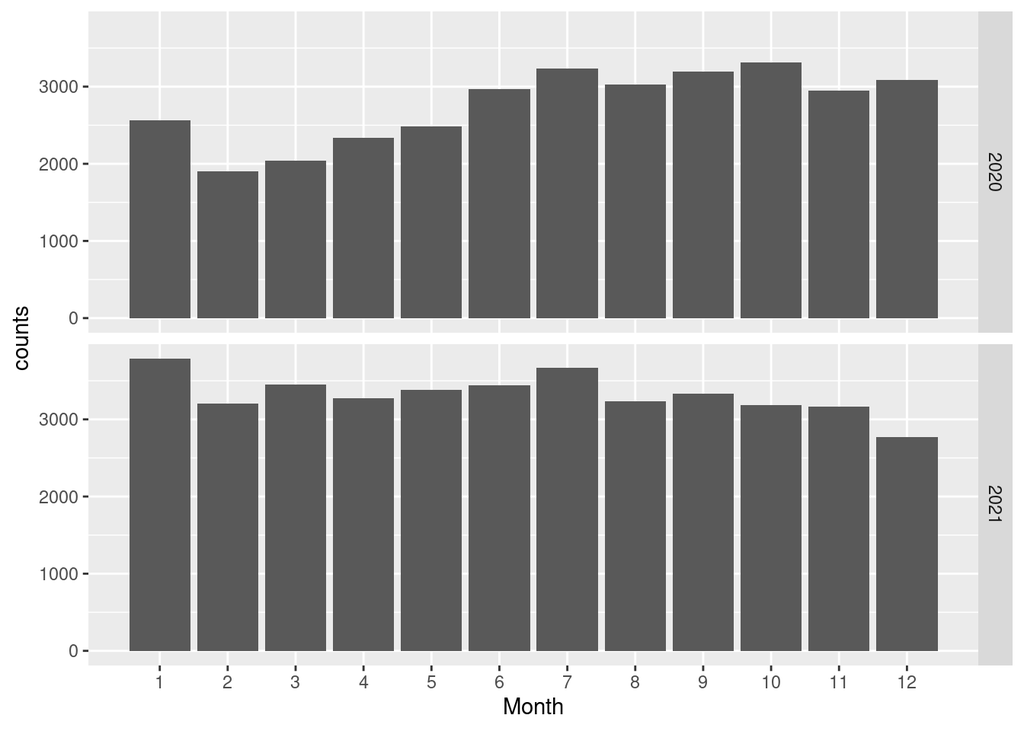

```r
summarybyMonth %>%
  ggplot(aes(x = month_firstpub, y = counts)) +
  geom_col(position = position_dodge()) +
  facet_grid(year_firstpub ~ .) +
  geom_bar(stat = "identity") +
  scale_x_discrete(name="Month", limits = 1:12, labels = 1:12)
```

```r
coi_summarybyMonth <- opendata %>%
  group_by(month_firstpub, year_firstpub, is_coi_pred) %>%
  summarise(counts = n())
```

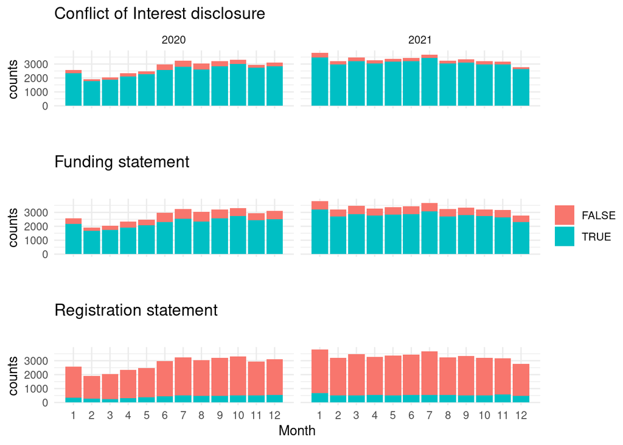

```r
coi_plot <- coi_summarybyMonth %>%
  ggplot(aes(x = month_firstpub, y = counts, fill = is_coi_pred)) +
  geom_col(position = position_dodge()) +
  facet_grid(. ~ year_firstpub) +
  geom_bar(stat = "identity") +
  scale_x_discrete(name="Month", limits = 1:12, labels = 1:12) +
  theme_minimal() +
  theme(legend.title = element_blank()) +
  labs(title = "Conflict of Interest disclosure")
fund_summarybyMonth <- opendata %>%
  group_by(month_firstpub, year_firstpub, is_fund_pred) %>%
  summarise(counts = n())
fund_plot <- fund_summarybyMonth %>%
  ggplot(aes(x = month_firstpub, y = counts, fill = is_fund_pred)) +
  geom_col(position = position_dodge()) +
  facet_grid(. ~ year_firstpub) +
  geom_bar(stat = "identity") +
  scale_x_discrete(name="Month", limits = 1:12, labels = 1:12) +
  theme_minimal() +
  theme(legend.title = element_blank()) +
  labs(title = "Funding statement")
reg_summarybyMonth <- opendata %>%
  group_by(month_firstpub, year_firstpub, is_register_pred) %>%
  summarise(counts = n())
reg_plot <- reg_summarybyMonth %>%
  ggplot(aes(x = month_firstpub, y = counts, fill = is_register_pred)) +
  geom_col(position = position_dodge()) +
  facet_grid(. ~ year_firstpub) +
  geom_bar(stat = "identity") +
  scale_x_discrete(name="Month", limits = 1:12, labels = 1:12) +
  theme_minimal() +
  theme(legend.title = element_blank()) +
  labs(title = "Registration statement")
library(ggpubr)
figure <- ggarrange(coi_plot + rremove("xlab") + theme(axis.text.x=element_blank()),
                    fund_plot + rremove("xlab") + theme(axis.text.x=element_blank(), strip.text.x = element_blank()),
                    reg_plot + theme(strip.text.x = element_blank()),
                    ncol = 1, nrow = 3, vjust = 1,
                    align = "hv", common.legend = T, legend = "right")

# tiff("Figure.tiff", width = 6, height = 7, units = "in", res = 300)
figure
```

```r
#dev.off()
```